# Risk Factor Analysis

## Outcome Variable

**Outcome Variable:** stunted

## Predictor Variables

**Intervention Variable:** tr

**Adjustment Set:**

unadjusted

## Stratifying Variables

The analysis was stratified on these variable(s):

- agecat
- studyid
- country
- intXhfoodsec

## Data Summary

| agecat | studyid | country | intXhfoodsec | stunted | n_cell | n |
| --- | --- | --- | --- | --- | --- | --- |
| Birth | iLiNS_DYADM_LNS | MALAWI | Food Insecure_Birth | 0 | 0 | 1 |
| Birth | iLiNS_DYADM_LNS | MALAWI | Food Insecure_Birth | 1 | 1 | 1 |
| Birth | ki1148112-iLiNS-DYAD-M | MALAWI | Food Insecure_Birth | 0 | 0 | 1 |
| Birth | ki1148112-iLiNS-DYAD-M | MALAWI | Food Insecure_Birth | 1 | 1 | 1 |
| Birth | kiGH5241-JiVitA-3 | BANGLADESH | Food Secure_Birth | 0 | 8466 | 11994 |
| Birth | kiGH5241-JiVitA-3 | BANGLADESH | Food Secure_Birth | 1 | 3528 | 11994 |
| Birth | kiGH5241-JiVitA-3 | BANGLADESH | Mildly Food Insecure_Birth | 0 | 5944 | 8670 |
| Birth | kiGH5241-JiVitA-3 | BANGLADESH | Mildly Food Insecure_Birth | 1 | 2726 | 8670 |
| Birth | kiGH5241-JiVitA-3 | BANGLADESH | Food Insecure_Birth | 0 | 3054 | 4546 |
| Birth | kiGH5241-JiVitA-3 | BANGLADESH | Food Insecure_Birth | 1 | 1492 | 4546 |
| Birth | kiGH5241-JiVitA-4 | BANGLADESH | Food Secure_Birth | 0 | 552 | 792 |
| Birth | kiGH5241-JiVitA-4 | BANGLADESH | Food Secure_Birth | 1 | 240 | 792 |
| Birth | kiGH5241-JiVitA-4 | BANGLADESH | Mildly Food Insecure_Birth | 0 | 428 | 618 |
| Birth | kiGH5241-JiVitA-4 | BANGLADESH | Mildly Food Insecure_Birth | 1 | 190 | 618 |
| Birth | kiGH5241-JiVitA-4 | BANGLADESH | Food Insecure_Birth | 0 | 164 | 228 |
| Birth | kiGH5241-JiVitA-4 | BANGLADESH | Food Insecure_Birth | 1 | 64 | 228 |
| 6 months | iLiNS_DYADM_LNS | MALAWI | Food Secure_6 months | 0 | 100 | 122 |
| 6 months | iLiNS_DYADM_LNS | MALAWI | Food Secure_6 months | 1 | 22 | 122 |
| 6 months | iLiNS_DYADM_LNS | MALAWI | Mildly Food Insecure_6 months | 0 | 68 | 89 |
| 6 months | iLiNS_DYADM_LNS | MALAWI | Mildly Food Insecure_6 months | 1 | 21 | 89 |
| 6 months | iLiNS_DYADM_LNS | MALAWI | Food Insecure_6 months | 0 | 151 | 210 |
| 6 months | iLiNS_DYADM_LNS | MALAWI | Food Insecure_6 months | 1 | 59 | 210 |
| 6 months | ki1000110-WASH-Bangladesh | BANGLADESH | Food Secure_6 months | 0 | 427 | 495 |
| 6 months | ki1000110-WASH-Bangladesh | BANGLADESH | Food Secure_6 months | 1 | 68 | 495 |
| 6 months | ki1000110-WASH-Bangladesh | BANGLADESH | Mildly Food Insecure_6 months | 0 | 45 | 46 |
| 6 months | ki1000110-WASH-Bangladesh | BANGLADESH | Mildly Food Insecure_6 months | 1 | 1 | 46 |
| 6 months | ki1000110-WASH-Bangladesh | BANGLADESH | Food Insecure_6 months | 0 | 110 | 141 |
| 6 months | ki1000110-WASH-Bangladesh | BANGLADESH | Food Insecure_6 months | 1 | 31 | 141 |
| 6 months | ki1148112-iLiNS-DOSE | MALAWI | Food Secure_6 months | 0 | 288 | 400 |
| 6 months | ki1148112-iLiNS-DOSE | MALAWI | Food Secure_6 months | 1 | 112 | 400 |

[output cut: 58 more lines]

The following strata were considered:

- agecat: 24 months, studyid: iLiNS_DYADM_LNS, country: MALAWI, intXhfoodsec: Food Insecure_24 months
- agecat: 24 months, studyid: iLiNS_DYADM_LNS, country: MALAWI, intXhfoodsec: Food Secure_24 months
- agecat: 24 months, studyid: iLiNS_DYADM_LNS, country: MALAWI, intXhfoodsec: Mildly Food Insecure_24 months
- agecat: 24 months, studyid: ki1000110-WASH-Bangladesh, country: BANGLADESH, intXhfoodsec: Food Insecure_24 months
- agecat: 24 months, studyid: ki1000110-WASH-Bangladesh, country: BANGLADESH, intXhfoodsec: Food Secure_24 months
- agecat: 24 months, studyid: ki1000110-WASH-Bangladesh, country: BANGLADESH, intXhfoodsec: Mildly Food Insecure_24 months
- agecat: 24 months, studyid: ki1148112-iLiNS-DOSE, country: MALAWI, intXhfoodsec: Food Insecure_24 months
- agecat: 24 months, studyid: ki1148112-iLiNS-DOSE, country: MALAWI, intXhfoodsec: Food Secure_24 months
- agecat: 24 months, studyid: ki1148112-iLiNS-DOSE, country: MALAWI, intXhfoodsec: Mildly Food Insecure_24 months
- agecat: 24 months, studyid: ki1148112-iLiNS-DYAD-M, country: MALAWI, intXhfoodsec: Food Insecure_24 months
- agecat: 24 months, studyid: ki1148112-iLiNS-DYAD-M, country: MALAWI, intXhfoodsec: Food Secure_24 months
- agecat: 24 months, studyid: ki1148112-iLiNS-DYAD-M, country: MALAWI, intXhfoodsec: Mildly Food Insecure_24 months
- agecat: 24 months, studyid: kiGH5241-JiVitA-3, country: BANGLADESH, intXhfoodsec: Food Insecure_24 months
- agecat: 24 months, studyid: kiGH5241-JiVitA-3, country: BANGLADESH, intXhfoodsec: Food Secure_24 months
- agecat: 24 months, studyid: kiGH5241-JiVitA-3, country: BANGLADESH, intXhfoodsec: Mildly Food Insecure_24 months
- agecat: 24 months, studyid: kiGH5241-JiVitA-4, country: BANGLADESH, intXhfoodsec: Food Insecure_24 months
- agecat: 24 months, studyid: kiGH5241-JiVitA-4, country: BANGLADESH, intXhfoodsec: Food Secure_24 months
- agecat: 24 months, studyid: kiGH5241-JiVitA-4, country: BANGLADESH, intXhfoodsec: Mildly Food Insecure_24 months
- agecat: 6 months, studyid: iLiNS_DYADM_LNS, country: MALAWI, intXhfoodsec: Food Insecure_6 months
- agecat: 6 months, studyid: iLiNS_DYADM_LNS, country: MALAWI, intXhfoodsec: Food Secure_6 months
- agecat: 6 months, studyid: iLiNS_DYADM_LNS, country: MALAWI, intXhfoodsec: Mildly Food Insecure_6 months
- agecat: 6 months, studyid: ki1000110-WASH-Bangladesh, country: BANGLADESH, intXhfoodsec: Food Insecure_6 months
- agecat: 6 months, studyid: ki1000110-WASH-Bangladesh, country: BANGLADESH, intXhfoodsec: Food Secure_6 months
- agecat: 6 months, studyid: ki1000110-WASH-Bangladesh, country: BANGLADESH, intXhfoodsec: Mildly Food Insecure_6 months
- agecat: 6 months, studyid: ki1148112-iLiNS-DOSE, country: MALAWI, intXhfoodsec: Food Insecure_6 months
- agecat: 6 months, studyid: ki1148112-iLiNS-DOSE, country: MALAWI, intXhfoodsec: Food Secure_6 months
- agecat: 6 months, studyid: ki1148112-iLiNS-DOSE, country: MALAWI, intXhfoodsec: Mildly Food Insecure_6 months
- agecat: 6 months, studyid: ki1148112-iLiNS-DYAD-M, country: MALAWI, intXhfoodsec: Food Insecure_6 months
- agecat: 6 months, studyid: ki1148112-iLiNS-DYAD-M, country: MALAWI, intXhfoodsec: Food Secure_6 months
- agecat: 6 months, studyid: ki1148112-iLiNS-DYAD-M, country: MALAWI, intXhfoodsec: Mildly Food Insecure_6 months
- agecat: 6 months, studyid: kiGH5241-JiVitA-3, country: BANGLADESH, intXhfoodsec: Food Insecure_6 months
- agecat: 6 months, studyid: kiGH5241-JiVitA-3, country: BANGLADESH, intXhfoodsec: Food Secure_6 months
- agecat: 6 months, studyid: kiGH5241-JiVitA-3, country: BANGLADESH, intXhfoodsec: Mildly Food Insecure_6 months
- agecat: 6 months, studyid: kiGH5241-JiVitA-4, country: BANGLADESH, intXhfoodsec: Food Insecure_6 months
- agecat: 6 months, studyid: kiGH5241-JiVitA-4, country: BANGLADESH, intXhfoodsec: Food Secure_6 months
- agecat: 6 months, studyid: kiGH5241-JiVitA-4, country: BANGLADESH, intXhfoodsec: Mildly Food Insecure_6 months
- agecat: Birth, studyid: iLiNS_DYADM_LNS, country: MALAWI, intXhfoodsec: Food Insecure_Birth
- agecat: Birth, studyid: ki1148112-iLiNS-DYAD-M, country: MALAWI, intXhfoodsec: Food Insecure_Birth
- agecat: Birth, studyid: kiGH5241-JiVitA-3, country: BANGLADESH, intXhfoodsec: Food Insecure_Birth
- agecat: Birth, studyid: kiGH5241-JiVitA-3, country: BANGLADESH, intXhfoodsec: Food Secure_Birth
- agecat: Birth, studyid: kiGH5241-JiVitA-3, country: BANGLADESH, intXhfoodsec: Mildly Food Insecure_Birth
- agecat: Birth, studyid: kiGH5241-JiVitA-4, country: BANGLADESH, intXhfoodsec: Food Insecure_Birth
- agecat: Birth, studyid: kiGH5241-JiVitA-4, country: BANGLADESH, intXhfoodsec: Food Secure_Birth
- agecat: Birth, studyid: kiGH5241-JiVitA-4, country: BANGLADESH, intXhfoodsec: Mildly Food Insecure_Birth

### Dropped Strata

Some strata were dropped due to rare outcomes:

- agecat: Birth, studyid: iLiNS_DYADM_LNS, country: MALAWI, intXhfoodsec: Food Insecure_Birth
- agecat: Birth, studyid: ki1148112-iLiNS-DYAD-M, country: MALAWI, intXhfoodsec: Food Insecure_Birth
- agecat: 6 months, studyid: ki1000110-WASH-Bangladesh, country: BANGLADESH, intXhfoodsec: Mildly Food Insecure_6 months
- agecat: 24 months, studyid: iLiNS_DYADM_LNS, country: MALAWI, intXhfoodsec: Food Secure_24 months
- agecat: 24 months, studyid: iLiNS_DYADM_LNS, country: MALAWI, intXhfoodsec: Mildly Food Insecure_24 months

## Methods Detail

We’re interested in the causal parameters $E[Y_a]$ for all values of $a \in \mathcal{A}$. These parameters represent the mean outcome if, possibly contrary to fact, we intervened to set all units to have $A=a$. Under the randomization and positivity assumptions, these are identified by the statistical parameters $\psi_a=E_W[E_{Y|A,W}(Y|A=a,W)]$. In addition, we’re interested in the mean of $Y$, $E[Y]$ under no intervention (the observed mean). We will estimate these parameters by using SuperLearner to fit the relevant likelihood factors – $E_{Y|A,W}(Y|A=a,W)$ and $p(A=a|W)$, and then updating our likelihood fit using a joint TMLE.

For unadjusted analyses ($W=\{\}$), initial likelihoods were estimated using Lrnr_glm to estimate the simple $E(Y|A)$ and Lrnr_mean to estimate $p(A)$. For adjusted analyses, a small library containing Lrnr_glmnet, Lrnr_xgboost, and Lrnr_mean was used.

Having estimated these parameters, we will then use the delta method to estimate relative risks and attributable risks relative to a prespecified baseline level of $A$.

# Results Detail

## Results Plots

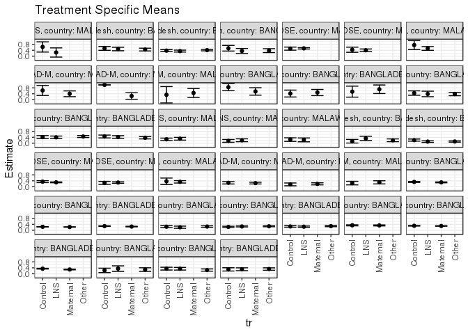

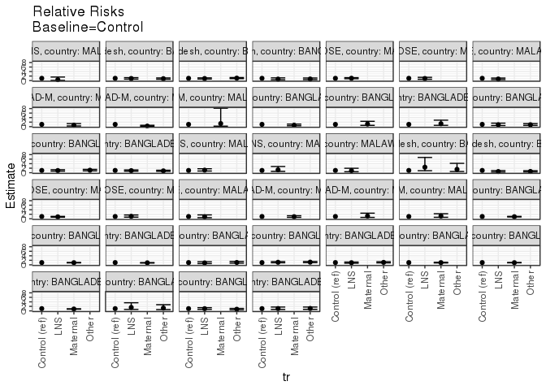

[figure not shown]

[figure not shown]

## Results Table

### Parameter: TSM

| agecat | studyid | country | intXhfoodsec | intervention_level | baseline_level | estimate | ci_lower | ci_upper |
| --- | --- | --- | --- | --- | --- | --- | --- | --- |
| Birth | kiGH5241-JiVitA-3 | BANGLADESH | Food Secure_Birth | Control | NA | 0.3013745 | 0.2808883 | 0.3218606 |
| Birth | kiGH5241-JiVitA-3 | BANGLADESH | Food Secure_Birth | Maternal | NA | 0.2869940 | 0.2699670 | 0.3040211 |
| Birth | kiGH5241-JiVitA-3 | BANGLADESH | Mildly Food Insecure_Birth | Control | NA | 0.3424721 | 0.3188173 | 0.3661269 |
| Birth | kiGH5241-JiVitA-3 | BANGLADESH | Mildly Food Insecure_Birth | Maternal | NA | 0.2867613 | 0.2615662 | 0.3119565 |
| Birth | kiGH5241-JiVitA-3 | BANGLADESH | Food Insecure_Birth | Control | NA | 0.3321555 | 0.2969753 | 0.3673357 |
| Birth | kiGH5241-JiVitA-3 | BANGLADESH | Food Insecure_Birth | Maternal | NA | 0.3242770 | 0.2915665 | 0.3569874 |
| Birth | kiGH5241-JiVitA-4 | BANGLADESH | Food Secure_Birth | Control | NA | 0.3448276 | 0.2508535 | 0.4388017 |
| Birth | kiGH5241-JiVitA-4 | BANGLADESH | Food Secure_Birth | LNS | NA | 0.3392857 | 0.2500926 | 0.4284788 |
| Birth | kiGH5241-JiVitA-4 | BANGLADESH | Food Secure_Birth | Other | NA | 0.2500000 | 0.1747163 | 0.3252837 |
| Birth | kiGH5241-JiVitA-4 | BANGLADESH | Mildly Food Insecure_Birth | Control | NA | 0.2933333 | 0.1823600 | 0.4043067 |
| Birth | kiGH5241-JiVitA-4 | BANGLADESH | Mildly Food Insecure_Birth | LNS | NA | 0.3033708 | 0.2074951 | 0.3992464 |
| Birth | kiGH5241-JiVitA-4 | BANGLADESH | Mildly Food Insecure_Birth | Other | NA | 0.3172414 | 0.2364901 | 0.3979927 |
| Birth | kiGH5241-JiVitA-4 | BANGLADESH | Food Insecure_Birth | Control | NA | 0.2258065 | 0.0762329 | 0.3753800 |
| Birth | kiGH5241-JiVitA-4 | BANGLADESH | Food Insecure_Birth | LNS | NA | 0.3461538 | 0.1596749 | 0.5326328 |
| Birth | kiGH5241-JiVitA-4 | BANGLADESH | Food Insecure_Birth | Other | NA | 0.2807018 | 0.1590437 | 0.4023598 |
| 6 months | iLiNS_DYADM_LNS | MALAWI | Food Secure_6 months | Control | NA | 0.1578947 | 0.0628419 | 0.2529475 |
| 6 months | iLiNS_DYADM_LNS | MALAWI | Food Secure_6 months | LNS | NA | 0.2000000 | 0.1023576 | 0.2976424 |
| 6 months | iLiNS_DYADM_LNS | MALAWI | Mildly Food Insecure_6 months | Control | NA | 0.2448980 | 0.1238105 | 0.3659854 |
| 6 months | iLiNS_DYADM_LNS | MALAWI | Mildly Food Insecure_6 months | LNS | NA | 0.2250000 | 0.0948591 | 0.3551409 |
| 6 months | iLiNS_DYADM_LNS | MALAWI | Food Insecure_6 months | Control | NA | 0.2649573 | 0.1848013 | 0.3451132 |
| 6 months | iLiNS_DYADM_LNS | MALAWI | Food Insecure_6 months | LNS | NA | 0.3010753 | 0.2076217 | 0.3945288 |
| 6 months | ki1000110-WASH-Bangladesh | BANGLADESH | Food Secure_6 months | Control | NA | 0.2100840 | 0.1368183 | 0.2833497 |
| 6 months | ki1000110-WASH-Bangladesh | BANGLADESH | Food Secure_6 months | LNS | NA | 0.1102941 | 0.0575933 | 0.1629949 |
| 6 months | ki1000110-WASH-Bangladesh | BANGLADESH | Food Secure_6 months | Other | NA | 0.1166667 | 0.0760114 | 0.1573220 |
| 6 months | ki1000110-WASH-Bangladesh | BANGLADESH | Food Insecure_6 months | Control | NA | 0.1333333 | 0.0112579 | 0.2554088 |
| 6 months | ki1000110-WASH-Bangladesh | BANGLADESH | Food Insecure_6 months | LNS | NA | 0.3250000 | 0.1793343 | 0.4706657 |
| 6 months | ki1000110-WASH-Bangladesh | BANGLADESH | Food Insecure_6 months | Other | NA | 0.1971831 | 0.1043062 | 0.2900600 |
| 6 months | ki1148112-iLiNS-DOSE | MALAWI | Food Secure_6 months | Control | NA | 0.2602740 | 0.1594924 | 0.3610555 |
| 6 months | ki1148112-iLiNS-DOSE | MALAWI | Food Secure_6 months | LNS | NA | 0.2844037 | 0.2354461 | 0.3333612 |
| 6 months | ki1148112-iLiNS-DOSE | MALAWI | Mildly Food Insecure_6 months | Control | NA | 0.3684211 | 0.1507906 | 0.5860515 |

[output cut: 62 more lines]

### Parameter: E(Y)

| agecat | studyid | country | intXhfoodsec | intervention_level | baseline_level | estimate | ci_lower | ci_upper |
| --- | --- | --- | --- | --- | --- | --- | --- | --- |
| Birth | kiGH5241-JiVitA-3 | BANGLADESH | Food Secure_Birth | NA | NA | 0.2941471 | 0.2808057 | 0.3074885 |
| Birth | kiGH5241-JiVitA-3 | BANGLADESH | Mildly Food Insecure_Birth | NA | NA | 0.3144175 | 0.2970608 | 0.3317743 |
| Birth | kiGH5241-JiVitA-3 | BANGLADESH | Food Insecure_Birth | NA | NA | 0.3282006 | 0.3041845 | 0.3522167 |
| Birth | kiGH5241-JiVitA-4 | BANGLADESH | Food Secure_Birth | NA | NA | 0.3030303 | 0.2535848 | 0.3524758 |
| Birth | kiGH5241-JiVitA-4 | BANGLADESH | Mildly Food Insecure_Birth | NA | NA | 0.3074434 | 0.2533436 | 0.3615431 |
| Birth | kiGH5241-JiVitA-4 | BANGLADESH | Food Insecure_Birth | NA | NA | 0.2807018 | 0.1956190 | 0.3657845 |
| 6 months | iLiNS_DYADM_LNS | MALAWI | Food Secure_6 months | NA | NA | 0.1803279 | 0.1118253 | 0.2488304 |
| 6 months | iLiNS_DYADM_LNS | MALAWI | Mildly Food Insecure_6 months | NA | NA | 0.2359551 | 0.1472434 | 0.3246667 |
| 6 months | iLiNS_DYADM_LNS | MALAWI | Food Insecure_6 months | NA | NA | 0.2809524 | 0.2200169 | 0.3418878 |
| 6 months | ki1000110-WASH-Bangladesh | BANGLADESH | Food Secure_6 months | NA | NA | 0.1373737 | 0.1070175 | 0.1677300 |
| 6 months | ki1000110-WASH-Bangladesh | BANGLADESH | Food Insecure_6 months | NA | NA | 0.2198582 | 0.1512553 | 0.2884610 |
| 6 months | ki1148112-iLiNS-DOSE | MALAWI | Food Secure_6 months | NA | NA | 0.2800000 | 0.2359438 | 0.3240562 |
| 6 months | ki1148112-iLiNS-DOSE | MALAWI | Mildly Food Insecure_6 months | NA | NA | 0.3355705 | 0.2594969 | 0.4116440 |
| 6 months | ki1148112-iLiNS-DOSE | MALAWI | Food Insecure_6 months | NA | NA | 0.3038898 | 0.2782176 | 0.3295620 |
| 6 months | ki1148112-iLiNS-DYAD-M | MALAWI | Food Secure_6 months | NA | NA | 0.1823204 | 0.1259150 | 0.2387259 |
| 6 months | ki1148112-iLiNS-DYAD-M | MALAWI | Mildly Food Insecure_6 months | NA | NA | 0.2750000 | 0.1947750 | 0.3552250 |
| 6 months | ki1148112-iLiNS-DYAD-M | MALAWI | Food Insecure_6 months | NA | NA | 0.2514970 | 0.2048967 | 0.2980974 |
| 6 months | kiGH5241-JiVitA-3 | BANGLADESH | Food Secure_6 months | NA | NA | 0.2245190 | 0.2140772 | 0.2349607 |
| 6 months | kiGH5241-JiVitA-3 | BANGLADESH | Mildly Food Insecure_6 months | NA | NA | 0.2638939 | 0.2493990 | 0.2783888 |
| 6 months | kiGH5241-JiVitA-3 | BANGLADESH | Food Insecure_6 months | NA | NA | 0.3086263 | 0.2869561 | 0.3302965 |
| 6 months | kiGH5241-JiVitA-4 | BANGLADESH | Food Secure_6 months | NA | NA | 0.2531646 | 0.2324869 | 0.2738422 |
| 6 months | kiGH5241-JiVitA-4 | BANGLADESH | Mildly Food Insecure_6 months | NA | NA | 0.2616210 | 0.2368622 | 0.2863797 |
| 6 months | kiGH5241-JiVitA-4 | BANGLADESH | Food Insecure_6 months | NA | NA | 0.2348609 | 0.1990155 | 0.2707063 |
| 24 months | iLiNS_DYADM_LNS | MALAWI | Food Insecure_24 months | NA | NA | 0.4375000 | 0.1864543 | 0.6885457 |
| 24 months | ki1000110-WASH-Bangladesh | BANGLADESH | Food Secure_24 months | NA | NA | 0.3867141 | 0.3538200 | 0.4196083 |
| 24 months | ki1000110-WASH-Bangladesh | BANGLADESH | Mildly Food Insecure_24 months | NA | NA | 0.4090909 | 0.3167902 | 0.5013916 |
| 24 months | ki1000110-WASH-Bangladesh | BANGLADESH | Food Insecure_24 months | NA | NA | 0.4786325 | 0.4144904 | 0.5427746 |
| 24 months | ki1148112-iLiNS-DOSE | MALAWI | Food Secure_24 months | NA | NA | 0.4088050 | 0.3321496 | 0.4854605 |
| 24 months | ki1148112-iLiNS-DOSE | MALAWI | Mildly Food Insecure_24 months | NA | NA | 0.5507246 | 0.4324975 | 0.6689518 |
| 24 months | ki1148112-iLiNS-DOSE | MALAWI | Food Insecure_24 months | NA | NA | 0.5268022 | 0.4846911 | 0.5689133 |
| 24 months | ki1148112-iLiNS-DYAD-M | MALAWI | Food Secure_24 months | NA | NA | 0.2941176 | 0.0708556 | 0.5173796 |
| 24 months | ki1148112-iLiNS-DYAD-M | MALAWI | Mildly Food Insecure_24 months | NA | NA | 0.4285714 | 0.1595611 | 0.6975818 |
| 24 months | ki1148112-iLiNS-DYAD-M | MALAWI | Food Insecure_24 months | NA | NA | 0.4545455 | 0.2820248 | 0.6270661 |
| 24 months | kiGH5241-JiVitA-3 | BANGLADESH | Food Secure_24 months | NA | NA | 0.4492754 | 0.2919615 | 0.6065892 |
| 24 months | kiGH5241-JiVitA-3 | BANGLADESH | Mildly Food Insecure_24 months | NA | NA | 0.6428571 | 0.4086980 | 0.8770163 |
| 24 months | kiGH5241-JiVitA-3 | BANGLADESH | Food Insecure_24 months | NA | NA | 0.6578947 | 0.4656219 | 0.8501676 |
| 24 months | kiGH5241-JiVitA-4 | BANGLADESH | Food Secure_24 months | NA | NA | 0.4281346 | 0.3806850 | 0.4755841 |
| 24 months | kiGH5241-JiVitA-4 | BANGLADESH | Mildly Food Insecure_24 months | NA | NA | 0.4051144 | 0.3541177 | 0.4561111 |
| 24 months | kiGH5241-JiVitA-4 | BANGLADESH | Food Insecure_24 months | NA | NA | 0.4037037 | 0.3222219 | 0.4851855 |

### Parameter: RR

| agecat | studyid | country | intXhfoodsec | intervention_level | baseline_level | estimate | ci_lower | ci_upper |
| --- | --- | --- | --- | --- | --- | --- | --- | --- |
| Birth | kiGH5241-JiVitA-3 | BANGLADESH | Food Secure_Birth | Control | Control | 1.0000000 | 1.0000000 | 1.0000000 |
| Birth | kiGH5241-JiVitA-3 | BANGLADESH | Food Secure_Birth | Maternal | Control | 0.9522839 | 0.8701428 | 1.0421790 |
| Birth | kiGH5241-JiVitA-3 | BANGLADESH | Mildly Food Insecure_Birth | Control | Control | 1.0000000 | 1.0000000 | 1.0000000 |
| Birth | kiGH5241-JiVitA-3 | BANGLADESH | Mildly Food Insecure_Birth | Maternal | Control | 0.8373275 | 0.7486640 | 0.9364914 |
| Birth | kiGH5241-JiVitA-3 | BANGLADESH | Food Insecure_Birth | Control | Control | 1.0000000 | 1.0000000 | 1.0000000 |
| Birth | kiGH5241-JiVitA-3 | BANGLADESH | Food Insecure_Birth | Maternal | Control | 0.9762806 | 0.8434352 | 1.1300499 |
| Birth | kiGH5241-JiVitA-4 | BANGLADESH | Food Secure_Birth | Control | Control | 1.0000000 | 1.0000000 | 1.0000000 |
| Birth | kiGH5241-JiVitA-4 | BANGLADESH | Food Secure_Birth | LNS | Control | 0.9839286 | 0.6738808 | 1.4366270 |
| Birth | kiGH5241-JiVitA-4 | BANGLADESH | Food Secure_Birth | Other | Control | 0.7250000 | 0.4829616 | 1.0883370 |
| Birth | kiGH5241-JiVitA-4 | BANGLADESH | Mildly Food Insecure_Birth | Control | Control | 1.0000000 | 1.0000000 | 1.0000000 |
| Birth | kiGH5241-JiVitA-4 | BANGLADESH | Mildly Food Insecure_Birth | LNS | Control | 1.0342186 | 0.6317806 | 1.6930056 |
| Birth | kiGH5241-JiVitA-4 | BANGLADESH | Mildly Food Insecure_Birth | Other | Control | 1.0815047 | 0.6854811 | 1.7063233 |
| Birth | kiGH5241-JiVitA-4 | BANGLADESH | Food Insecure_Birth | Control | Control | 1.0000000 | 1.0000000 | 1.0000000 |
| Birth | kiGH5241-JiVitA-4 | BANGLADESH | Food Insecure_Birth | LNS | Control | 1.5329670 | 0.6527284 | 3.6002540 |
| Birth | kiGH5241-JiVitA-4 | BANGLADESH | Food Insecure_Birth | Other | Control | 1.2431078 | 0.5632910 | 2.7433724 |
| 6 months | iLiNS_DYADM_LNS | MALAWI | Food Secure_6 months | Control | Control | 1.0000000 | 1.0000000 | 1.0000000 |
| 6 months | iLiNS_DYADM_LNS | MALAWI | Food Secure_6 months | LNS | Control | 1.2666667 | 0.5835086 | 2.7496498 |
| 6 months | iLiNS_DYADM_LNS | MALAWI | Mildly Food Insecure_6 months | Control | Control | 1.0000000 | 1.0000000 | 1.0000000 |
| 6 months | iLiNS_DYADM_LNS | MALAWI | Mildly Food Insecure_6 months | LNS | Control | 0.9187500 | 0.4292668 | 1.9663797 |
| 6 months | iLiNS_DYADM_LNS | MALAWI | Food Insecure_6 months | Control | Control | 1.0000000 | 1.0000000 | 1.0000000 |
| 6 months | iLiNS_DYADM_LNS | MALAWI | Food Insecure_6 months | LNS | Control | 1.1363163 | 0.7366471 | 1.7528269 |
| 6 months | ki1000110-WASH-Bangladesh | BANGLADESH | Food Secure_6 months | Control | Control | 1.0000000 | 1.0000000 | 1.0000000 |
| 6 months | ki1000110-WASH-Bangladesh | BANGLADESH | Food Secure_6 months | LNS | Control | 0.5250000 | 0.2905701 | 0.9485662 |
| 6 months | ki1000110-WASH-Bangladesh | BANGLADESH | Food Secure_6 months | Other | Control | 0.5553333 | 0.3391900 | 0.9092106 |
| 6 months | ki1000110-WASH-Bangladesh | BANGLADESH | Food Insecure_6 months | Control | Control | 1.0000000 | 1.0000000 | 1.0000000 |
| 6 months | ki1000110-WASH-Bangladesh | BANGLADESH | Food Insecure_6 months | LNS | Control | 2.4375000 | 0.8794907 | 6.7555080 |
| 6 months | ki1000110-WASH-Bangladesh | BANGLADESH | Food Insecure_6 months | Other | Control | 1.4788732 | 0.5281681 | 4.1408519 |
| 6 months | ki1148112-iLiNS-DOSE | MALAWI | Food Secure_6 months | Control | Control | 1.0000000 | 1.0000000 | 1.0000000 |
| 6 months | ki1148112-iLiNS-DOSE | MALAWI | Food Secure_6 months | LNS | Control | 1.0927088 | 0.7152714 | 1.6693142 |
| 6 months | ki1148112-iLiNS-DOSE | MALAWI | Mildly Food Insecure_6 months | Control | Control | 1.0000000 | 1.0000000 | 1.0000000 |

[output cut: 62 more lines]

### Parameter: PAR

| agecat | studyid | country | intXhfoodsec | intervention_level | baseline_level | estimate | ci_lower | ci_upper |
| --- | --- | --- | --- | --- | --- | --- | --- | --- |
| Birth | kiGH5241-JiVitA-3 | BANGLADESH | Food Secure_Birth | Control | NA | -0.0072274 | -0.0206340 | 0.0061793 |
| Birth | kiGH5241-JiVitA-3 | BANGLADESH | Mildly Food Insecure_Birth | Control | NA | -0.0280546 | -0.0458084 | -0.0103007 |
| Birth | kiGH5241-JiVitA-3 | BANGLADESH | Food Insecure_Birth | Control | NA | -0.0039549 | -0.0280753 | 0.0201656 |
| Birth | kiGH5241-JiVitA-4 | BANGLADESH | Food Secure_Birth | Control | NA | -0.0417973 | -0.1196782 | 0.0360836 |
| Birth | kiGH5241-JiVitA-4 | BANGLADESH | Mildly Food Insecure_Birth | Control | NA | 0.0141100 | -0.0821495 | 0.1103695 |
| Birth | kiGH5241-JiVitA-4 | BANGLADESH | Food Insecure_Birth | Control | NA | 0.0548953 | -0.0771513 | 0.1869419 |
| 6 months | iLiNS_DYADM_LNS | MALAWI | Food Secure_6 months | Control | NA | 0.0224331 | -0.0502653 | 0.0951316 |
| 6 months | iLiNS_DYADM_LNS | MALAWI | Mildly Food Insecure_6 months | Control | NA | -0.0089429 | -0.0888621 | 0.0709763 |
| 6 months | iLiNS_DYADM_LNS | MALAWI | Food Insecure_6 months | Control | NA | 0.0159951 | -0.0385837 | 0.0705739 |
| 6 months | ki1000110-WASH-Bangladesh | BANGLADESH | Food Secure_6 months | Control | NA | -0.0727103 | -0.1336074 | -0.0118132 |
| 6 months | ki1000110-WASH-Bangladesh | BANGLADESH | Food Insecure_6 months | Control | NA | 0.0865248 | -0.0286590 | 0.2017087 |
| 6 months | ki1148112-iLiNS-DOSE | MALAWI | Food Secure_6 months | Control | NA | 0.0197260 | -0.0718741 | 0.1113262 |
| 6 months | ki1148112-iLiNS-DOSE | MALAWI | Mildly Food Insecure_6 months | Control | NA | -0.0328506 | -0.2355105 | 0.1698093 |
| 6 months | ki1148112-iLiNS-DOSE | MALAWI | Food Insecure_6 months | Control | NA | -0.0407704 | -0.0996521 | 0.0181113 |
| 6 months | ki1148112-iLiNS-DYAD-M | MALAWI | Food Secure_6 months | Control | NA | 0.0244257 | -0.0563025 | 0.1051540 |
| 6 months | ki1148112-iLiNS-DYAD-M | MALAWI | Mildly Food Insecure_6 months | Control | NA | 0.0301020 | -0.0653770 | 0.1255811 |
| 6 months | ki1148112-iLiNS-DYAD-M | MALAWI | Food Insecure_6 months | Control | NA | -0.0134603 | -0.0774277 | 0.0505071 |
| 6 months | kiGH5241-JiVitA-3 | BANGLADESH | Food Secure_6 months | Control | NA | -0.0064251 | -0.0169087 | 0.0040584 |
| 6 months | kiGH5241-JiVitA-3 | BANGLADESH | Mildly Food Insecure_6 months | Control | NA | -0.0157132 | -0.0304831 | -0.0009433 |
| 6 months | kiGH5241-JiVitA-3 | BANGLADESH | Food Insecure_6 months | Control | NA | -0.0149031 | -0.0369735 | 0.0071673 |
| 6 months | kiGH5241-JiVitA-4 | BANGLADESH | Food Secure_6 months | Control | NA | 0.0274364 | -0.0083526 | 0.0632254 |
| 6 months | kiGH5241-JiVitA-4 | BANGLADESH | Mildly Food Insecure_6 months | Control | NA | 0.0056401 | -0.0385226 | 0.0498028 |
| 6 months | kiGH5241-JiVitA-4 | BANGLADESH | Food Insecure_6 months | Control | NA | -0.0033744 | -0.0616571 | 0.0549083 |
| 24 months | iLiNS_DYADM_LNS | MALAWI | Food Insecure_24 months | Control | NA | -0.1875000 | -0.4385457 | 0.0635457 |
| 24 months | ki1000110-WASH-Bangladesh | BANGLADESH | Food Secure_24 months | Control | NA | 0.0090545 | -0.0521471 | 0.0702562 |
| 24 months | ki1000110-WASH-Bangladesh | BANGLADESH | Mildly Food Insecure_24 months | Control | NA | -0.1293706 | -0.2968750 | 0.0381338 |
| 24 months | ki1000110-WASH-Bangladesh | BANGLADESH | Food Insecure_24 months | Control | NA | -0.0476833 | -0.1606767 | 0.0653101 |
| 24 months | ki1148112-iLiNS-DOSE | MALAWI | Food Secure_24 months | Control | NA | -0.0286950 | -0.1824446 | 0.1250546 |
| 24 months | ki1148112-iLiNS-DOSE | MALAWI | Mildly Food Insecure_24 months | Control | NA | -0.1992754 | -0.4893639 | 0.0908132 |
| 24 months | ki1148112-iLiNS-DOSE | MALAWI | Food Insecure_24 months | Control | NA | 0.0154386 | -0.0801965 | 0.1110737 |
| 24 months | ki1148112-iLiNS-DYAD-M | MALAWI | Food Secure_24 months | Control | NA | -0.7058823 | -0.9291443 | -0.4826204 |
| 24 months | ki1148112-iLiNS-DYAD-M | MALAWI | Mildly Food Insecure_24 months | Control | NA | 0.0952381 | -0.4022313 | 0.5927075 |
| 24 months | ki1148112-iLiNS-DYAD-M | MALAWI | Food Insecure_24 months | Control | NA | -0.1704545 | -0.4697064 | 0.1287974 |
| 24 months | kiGH5241-JiVitA-3 | BANGLADESH | Food Secure_24 months | Control | NA | 0.0326087 | -0.1170675 | 0.1822849 |
| 24 months | kiGH5241-JiVitA-3 | BANGLADESH | Mildly Food Insecure_24 months | Control | NA | 0.0974026 | -0.1891181 | 0.3839233 |
| 24 months | kiGH5241-JiVitA-3 | BANGLADESH | Food Insecure_24 months | Control | NA | -0.1882591 | -0.4192080 | 0.0426898 |
| 24 months | kiGH5241-JiVitA-4 | BANGLADESH | Food Secure_24 months | Control | NA | 0.0151791 | -0.0710429 | 0.1014011 |
| 24 months | kiGH5241-JiVitA-4 | BANGLADESH | Mildly Food Insecure_24 months | Control | NA | -0.0480106 | -0.1329445 | 0.0369233 |
| 24 months | kiGH5241-JiVitA-4 | BANGLADESH | Food Insecure_24 months | Control | NA | -0.0462963 | -0.1710850 | 0.0784924 |

### Parameter: PAF

| agecat | studyid | country | intXhfoodsec | intervention_level | baseline_level | estimate | ci_lower | ci_upper |
| --- | --- | --- | --- | --- | --- | --- | --- | --- |
| Birth | kiGH5241-JiVitA-3 | BANGLADESH | Food Secure_Birth | Control | NA | -0.0245706 | -0.0709897 | 0.0198365 |
| Birth | kiGH5241-JiVitA-3 | BANGLADESH | Mildly Food Insecure_Birth | Control | NA | -0.0892272 | -0.1478836 | -0.0335681 |
| Birth | kiGH5241-JiVitA-3 | BANGLADESH | Food Insecure_Birth | Control | NA | -0.0120501 | -0.0882184 | 0.0587869 |
| Birth | kiGH5241-JiVitA-4 | BANGLADESH | Food Secure_Birth | Control | NA | -0.1379310 | -0.4263353 | 0.0921581 |
| Birth | kiGH5241-JiVitA-4 | BANGLADESH | Mildly Food Insecure_Birth | Control | NA | 0.0458947 | -0.3249632 | 0.3129493 |
| Birth | kiGH5241-JiVitA-4 | BANGLADESH | Food Insecure_Birth | Control | NA | 0.1955645 | -0.4394278 | 0.5504349 |
| 6 months | iLiNS_DYADM_LNS | MALAWI | Food Secure_6 months | Control | NA | 0.1244019 | -0.3848982 | 0.4464055 |
| 6 months | iLiNS_DYADM_LNS | MALAWI | Mildly Food Insecure_6 months | Control | NA | -0.0379009 | -0.4382588 | 0.2510122 |
| 6 months | iLiNS_DYADM_LNS | MALAWI | Food Insecure_6 months | Control | NA | 0.0569318 | -0.1586609 | 0.2324090 |
| 6 months | ki1000110-WASH-Bangladesh | BANGLADESH | Food Secure_6 months | Control | NA | -0.5292882 | -1.0328736 | -0.1504515 |
| 6 months | ki1000110-WASH-Bangladesh | BANGLADESH | Food Insecure_6 months | Control | NA | 0.3935484 | -0.4162112 | 0.7403046 |
| 6 months | ki1148112-iLiNS-DOSE | MALAWI | Food Secure_6 months | Control | NA | 0.0704501 | -0.3215784 | 0.3461886 |
| 6 months | ki1148112-iLiNS-DOSE | MALAWI | Mildly Food Insecure_6 months | Control | NA | -0.0978947 | -0.9031526 | 0.3666441 |
| 6 months | ki1148112-iLiNS-DOSE | MALAWI | Food Insecure_6 months | Control | NA | -0.1341618 | -0.3454531 | 0.0439481 |
| 6 months | ki1148112-iLiNS-DYAD-M | MALAWI | Food Secure_6 months | Control | NA | 0.1339713 | -0.4420489 | 0.4799027 |
| 6 months | ki1148112-iLiNS-DYAD-M | MALAWI | Mildly Food Insecure_6 months | Control | NA | 0.1094620 | -0.3144365 | 0.3966556 |
| 6 months | ki1148112-iLiNS-DYAD-M | MALAWI | Food Insecure_6 months | Control | NA | -0.0535206 | -0.3411255 | 0.1724074 |
| 6 months | kiGH5241-JiVitA-3 | BANGLADESH | Food Secure_6 months | Control | NA | -0.0286174 | -0.0765345 | 0.0171669 |
| 6 months | kiGH5241-JiVitA-3 | BANGLADESH | Mildly Food Insecure_6 months | Control | NA | -0.0595436 | -0.1170851 | -0.0049661 |
| 6 months | kiGH5241-JiVitA-3 | BANGLADESH | Food Insecure_6 months | Control | NA | -0.0482885 | -0.1222466 | 0.0207956 |
| 6 months | kiGH5241-JiVitA-4 | BANGLADESH | Food Secure_6 months | Control | NA | 0.1083738 | -0.0456054 | 0.2396775 |
| 6 months | kiGH5241-JiVitA-4 | BANGLADESH | Mildly Food Insecure_6 months | Control | NA | 0.0215583 | -0.1628101 | 0.1766944 |
| 6 months | kiGH5241-JiVitA-4 | BANGLADESH | Food Insecure_6 months | Control | NA | -0.0143677 | -0.2954780 | 0.2057435 |
| 24 months | iLiNS_DYADM_LNS | MALAWI | Food Insecure_24 months | Control | NA | -0.4285714 | -1.2281084 | 0.0840588 |
| 24 months | ki1000110-WASH-Bangladesh | BANGLADESH | Food Secure_24 months | Control | NA | 0.0234140 | -0.1483952 | 0.1695192 |
| 24 months | ki1000110-WASH-Bangladesh | BANGLADESH | Mildly Food Insecure_24 months | Control | NA | -0.3162393 | -0.8034817 | 0.0393659 |
| 24 months | ki1000110-WASH-Bangladesh | BANGLADESH | Food Insecure_24 months | Control | NA | -0.0996241 | -0.3634325 | 0.1131405 |
| 24 months | ki1148112-iLiNS-DOSE | MALAWI | Food Secure_24 months | Control | NA | -0.0701923 | -0.5210019 | 0.2470019 |
| 24 months | ki1148112-iLiNS-DOSE | MALAWI | Mildly Food Insecure_24 months | Control | NA | -0.3618421 | -1.0245293 | 0.0839283 |
| 24 months | ki1148112-iLiNS-DOSE | MALAWI | Food Insecure_24 months | Control | NA | 0.0293062 | -0.1703392 | 0.1948946 |
| 24 months | ki1148112-iLiNS-DYAD-M | MALAWI | Food Secure_24 months | Control | NA | -2.3999999 | -6.2635318 | -0.5915122 |
| 24 months | ki1148112-iLiNS-DYAD-M | MALAWI | Mildly Food Insecure_24 months | Control | NA | 0.2222222 | -2.4656098 | 0.8254454 |
| 24 months | ki1148112-iLiNS-DYAD-M | MALAWI | Food Insecure_24 months | Control | NA | -0.3750000 | -1.2512771 | 0.1601989 |
| 24 months | kiGH5241-JiVitA-3 | BANGLADESH | Food Secure_24 months | Control | NA | 0.0725806 | -0.3353008 | 0.3558705 |
| 24 months | kiGH5241-JiVitA-3 | BANGLADESH | Mildly Food Insecure_24 months | Control | NA | 0.1515152 | -0.4412512 | 0.5004850 |
| 24 months | kiGH5241-JiVitA-3 | BANGLADESH | Food Insecure_24 months | Control | NA | -0.2861538 | -0.7419465 | 0.0503774 |
| 24 months | kiGH5241-JiVitA-4 | BANGLADESH | Food Secure_24 months | Control | NA | 0.0354540 | -0.1890180 | 0.2175485 |
| 24 months | kiGH5241-JiVitA-4 | BANGLADESH | Mildly Food Insecure_24 months | Control | NA | -0.1185112 | -0.3505442 | 0.0736569 |
| 24 months | kiGH5241-JiVitA-4 | BANGLADESH | Food Insecure_24 months | Control | NA | -0.1146789 | -0.4725029 | 0.1561925 |